# Effect Heterogeneity and Randomized Estimation

Lecture 8 vignette

Author

Causal Inference — STATS 420

[figure not shown]

This vignette has two parts. The first part investigates **effect heterogeneity**. The second part investigates causal effect estimation from **interventional data**.

# 1 Observational study: oxygen therapy in the ICU

## 1.1 Constructing the patient-level cohort

In MIMIC-IV data, we identify ICU stays with a PaO2 reading below 90 mmHg before recorded supplemental oxygen. A patient is considered to be treated if they receive oxygen within three hours. For an untreated case, we select a comparison time with no oxygen recorded in the next twelve hours. The outcome $Y$ is the first subsequent PaO2 reading. Covariates summarize the three hours *before* the treatment or comparison time.

We read the patient-level Parquet snapshot directly. No access to MIMIC-IV or `ricu` is needed to run the analysis.

```python
res = pd.read_parquet(Path("../data/oxygen-heterogeneity.parquet"))
z_oxygen = ["pco2", "o2sat", "resp", "po2", "sofa", "sex", "age"]

oxygen_summary = (
    res.groupby("treat", as_index=False)
    .agg(
        Patients=("treat", "size"),
        **{
            "Mean age": ("age", "mean"),
            "Mean pre-treatment PaO2": ("po2", "mean"),
            "Mean subsequent PaO2": ("out_post", "mean"),
        },
    )
    .round(1)
)
oxygen_summary.insert(
    0, "Oxygen", oxygen_summary.pop("treat").map({0: "No", 1: "Yes"})
)
show_table(oxygen_summary, "The oxygen-therapy cohort.")
```

Table 1: The oxygen-therapy cohort.

| Oxygen | Patients | Mean age | Mean pre-treatment PaO2 | Mean subsequent PaO2 |
| --- | --- | --- | --- | --- |
| No | 672 | 50.900000 | 58.900000 | 76.900000 |
| Yes | 904 | 61.200000 | 93.500000 | 124.200000 |

$X=1$ means supplemental oxygen and $Y$ is subsequent PaO2. The pre-treatment measurements form $Z$. The observed treated and untreated groups may differ even before therapy, because clinicians choose who receives oxygen. The qualifying PaO2 was below 90, but the mean of a later pre-treatment window can be higher. We can compare patient characteristics (such as age and SOFA score) in the treated and untreated groups.

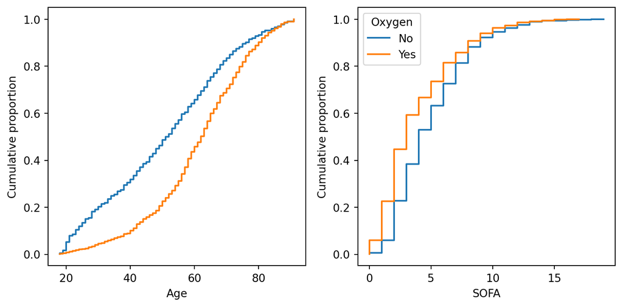

## 1.2 Conditional effects via a causal forest

We seek a conditional treatment effect

$$\begin{align}
\tau(z)
&=\mathbb{E}[Y_{x_1}-Y_{x_0}\mid Z=z].
\end{align}$$

EconML’s causal forest learns where treatment contrasts differ after estimating the treatment and outcome nuisance functions. We give it only measurements taken before the treatment decision. Its implementation differs from R’s `grf`, so the numerical estimates need not be identical.

```python
oxygen_x = res[z_oxygen].to_numpy()
oxygen_y = res["out_post"].to_numpy()
oxygen_w = res["treat"].to_numpy()

oxygen_forest = CausalForestDML(
    model_y=RandomForestRegressor(
        n_estimators=300, min_samples_leaf=5, random_state=2026, n_jobs=1
    ),
    model_t=RandomForestClassifier(
        n_estimators=300, min_samples_leaf=5, random_state=2027, n_jobs=1
    ),
    discrete_treatment=True,
    n_estimators=1000,
    min_samples_leaf=5,
    cv=5,
    random_state=2026,
    n_jobs=1,
)
oxygen_forest.fit(oxygen_y, oxygen_w, X=oxygen_x)
res["cate"] = oxygen_forest.effect(oxygen_x)
```

The average of the predicted conditional effects describes the forests’ mean response in this cohort. Averaging those same predictions among the treated patients describes the model’s predicted effect for their covariate mix:

```python
show_table(
    pd.DataFrame({
        "Population": ["All patients", "Treated patients", "Untreated patients"],
        "Mean predicted effect (mmHg)": np.round([
            res["cate"].mean(),
            res.loc[res["treat"] == 1, "cate"].mean(),
            res.loc[res["treat"] == 0, "cate"].mean(),
        ], 1),
    }),
    "Averaging forest-predicted conditional effects over different populations.",
)
```

Table 2: Averaging forest-predicted conditional effects over different populations.

| Population | Mean predicted effect (mmHg) |
| --- | --- |
| All patients | 27.400000 |
| Treated patients | 27.100000 |
| Untreated patients | 27.700000 |

Because the groups have different distributions of $Z$, the effects within groups can differ. This is the ATE vs. ETT difference we studied.

We can also inspect how effects change across SOFA score and age deciles:

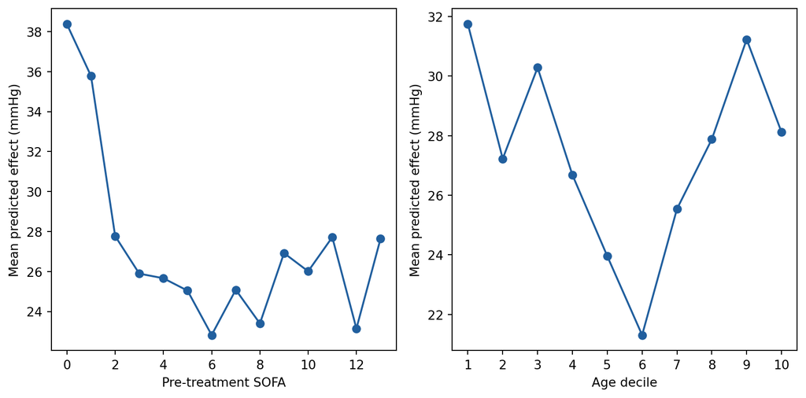

Causal forests rest upon the same assumptions of no unobserved confounding as the back-door adjustment methods we studied.

**NoteQuestions**

1. Why might the effect averaged among treated patients differ from the effect averaged over everyone?
2. Which patient characteristics could influence both the oxygen decision and subsequent PaO2?
3. Can we learn anything from the SOFA/age heterogeneity? What is missing for us to reach robust conclusions?

# 2 Randomized study: ACTG 175

The ACTG 175 study randomized patients with HIV to antiretroviral regimens. We compare two treatment regimes: $X=0$ is zidovudine alone and $X=1$ is zidovudine plus didanosine. The continuous outcome $Y$ is CD4 T-cell count 20 weeks later. T-cells are key for immune response, and higher counts are better. The baseline CD4 count (`cd40`) is particularly predictive of this outcome.

We load the two-arm Parquet snapshot directly:

```python
actg = pd.read_parquet(Path("../data/actg175-arms01.parquet"))
actg["X"] = (actg["arms"] == 1).astype(int)
actg["Y"] = actg["cd420"].astype(float)
z_actg = [
    "cd40", "cd80", "age", "wtkg", "karnof", "race", "gender",
    "str2", "symptom", "preanti",
]
assert actg[["X", "Y", *z_actg]].notna().all().all()

actg_summary = (
    actg.groupby("X", as_index=False)
    .agg(
        Patients=("X", "size"),
        **{
            "Mean baseline CD4": ("cd40", "mean"),
            "Mean week-20 CD4": ("Y", "mean"),
        },
    )
    .round(1)
)
actg_summary.insert(
    0, "Arm", actg_summary.pop("X").map({0: "Zidovudine", 1: "Combination"})
)
show_table(actg_summary, "The two randomized ACTG 175 arms.")
```

Table 3: The two randomized ACTG 175 arms.

| Arm | Patients | Mean baseline CD4 | Mean week-20 CD4 |
| --- | --- | --- | --- |
| Zidovudine | 532 | 353.200000 | 336.100000 |
| Combination | 522 | 348.700000 | 403.200000 |

Recall: this is interventional data, so group averages correspond to causal effects.

**NoteQuestions**

1. Which treatment works better?

## 2.1 Adjustment improves precision

Randomization makes treatment independent of baseline patient characteristics in expectation. We do **not** adjust to repair confounding. Rather, baseline variables can account for outcome variation and make the treatment estimate more precise.

### 2.1.1 Linear regression

```python
unadjusted = sm.OLS(actg["Y"], sm.add_constant(actg[["X"]])).fit()
adjusted = sm.OLS(
    actg["Y"], sm.add_constant(actg[["X", *z_actg]].astype(float))
).fit()


def summarize_x(fit, label):
    lower, upper = fit.conf_int().loc["X"].to_numpy()
    return {
        "Model": label,
        "Treatment estimate": fit.params["X"],
        "SE": fit.bse["X"],
        "95% CI lower": lower,
        "95% CI upper": upper,
        "CI width": upper - lower,
    }


comparison = pd.DataFrame([
    summarize_x(unadjusted, "Unadjusted"),
    summarize_x(adjusted, "Baseline adjusted"),
])
```

The interval-width reduction is 19.3%. The treatment estimate is similar in the two fits; the main change is that the adjusted estimate is more precise. Crucially, `cd420` is the **outcome**, not a covariate: using a post-treatment CD4 measure in $Z$ would invalidate this comparison.

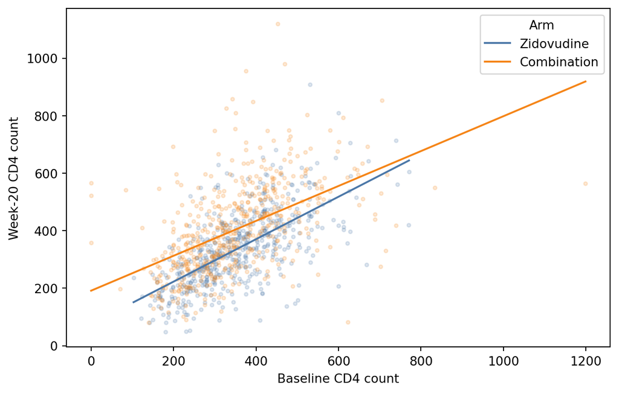

### 2.1.2 Flexible outcome adjustment

The linear model assumes a particular relationship between baseline variables and week-20 CD4. We can relax that assumption by using regression forests to estimate $m_x(z)=\mathbb{E}[Y\mid X=x,Z=z]$ separately in the two randomized arms. We fit each forest on four-fifths of the patients and predict for the held-out fifth. This **cross-fitting** prevents a patient’s outcome from being used to predict that same patient’s outcome.

The mean of $\hat m_1(Z_i)-\hat m_0(Z_i)$ is a regression-adjusted effect. We add a residual correction, using the treatment probability $\hat p$, to make the estimate less dependent on the forests fitting perfectly:

$$\begin{align}
\hat\psi_i
&=\hat m_1(Z_i)-\hat m_0(Z_i)
+\frac{X_i\{Y_i-\hat m_1(Z_i)\}}{\hat p}
-\frac{(1-X_i)\{Y_i-\hat m_0(Z_i)\}}{1-\hat p},\\
\widehat{\operatorname{ATE}}_{\mathrm{flex}}
&=\frac{1}{n}\sum_{i=1}^{n}\hat\psi_i.
\end{align}$$

This estimates the **same average causal effect** as the two regressions; the forests are flexible outcome models, not a claim of effect heterogeneity.

```python
actg_x = actg[z_actg].to_numpy(dtype=float)
actg_y = actg["Y"].to_numpy()
actg_w = actg["X"].to_numpy()
mu = np.full((len(actg), 2), np.nan)

folds = KFold(n_splits=5, shuffle=True, random_state=2026)
for fold, (train, test) in enumerate(folds.split(actg_x), start=1):
    for arm in (0, 1):
        arm_train = train[actg_w[train] == arm]
        forest = RandomForestRegressor(
            n_estimators=1000,
            min_samples_leaf=5,
            max_features=1.0,
            random_state=2026 + 2 * fold + arm,
            n_jobs=1,
        )
        forest.fit(actg_x[arm_train], actg_y[arm_train])
        mu[test, arm] = forest.predict(actg_x[test])

p = actg_w.mean()
score = (
    mu[:, 1] - mu[:, 0]
    + actg_w * (actg_y - mu[:, 1]) / p
    - (1 - actg_w) * (actg_y - mu[:, 0]) / (1 - p)
)
flex_estimate = score.mean()
flex_se = score.std(ddof=1) / np.sqrt(len(score))
flex_ci = flex_estimate + norm.ppf([0.025, 0.975]) * flex_se

comparison = pd.concat([
    comparison,
    pd.DataFrame([{
        "Model": "Flexible adjusted",
        "Treatment estimate": flex_estimate,
        "SE": flex_se,
        "95% CI lower": flex_ci[0],
        "95% CI upper": flex_ci[1],
        "CI width": flex_ci[1] - flex_ci[0],
    }]),
], ignore_index=True)
```

Table 4: Estimated CD4-cell gain from combination therapy.

| Model | Estimate | SE | 95% CI | CI width |
| --- | --- | --- | --- | --- |
| Unadjusted | 67.000000 | 8.900000 | [49.6, 84.4] | 34.800000 |
| Baseline adjusted | 70.300000 | 7.200000 | [56.3, 84.4] | 28.100000 |
| Flexible adjusted | 73.400000 | 7.100000 | [59.4, 87.4] | 28.000000 |

Both adjusted estimates have narrower intervals than the unadjusted difference in means. The flexible approach gives a similar conclusion, but in this sample it does not materially improve precision beyond the simpler linear model. This is useful: flexibility is an option, not a guarantee of a better estimate.

**NoteQuestions**

1. Why can baseline CD4 improve precision even though treatment was randomized?
2. Would adjusting for CD4 measured after treatment have the same interpretation?
3. Why might a flexible outcome model fail to improve precision over a linear model?